# Analytics Edge HW4 and some notes

## Please note that the analysis of the ‘states revisited’ dataset is the most complete and is the easiest to study from of the datsets analyzed in this writeup.

## TODO: Look at all text preceded by ‘NOTE:’

```r
library(magrittr)
library(dplyr)
library(caTools) #for splitting into train/test sets
library(ROCR) #for computing AUCs
```

```r
library(rpart) #contains rpart function used to build classification and regression trees
library(rpart.plot) #contains prp function used to plot classification and regression trees
library(randomForest) #for building random forest models
library(caret) #for cross-validation
library(e1071) #for cross-validation
```

## Gerber Voting Dataset (examines the influence of eligible voters’ receiving any of four types of messages- or no message- on whether or not they voted)

### Problem 1

```r
gerber = read.csv('gerber.csv')
mean(gerber$voting)
```

```
## [1] 0.3158996
```

```r
head(gerber)
```

```
##   sex  yob voting hawthorne civicduty neighbors self control
## 1   0 1941      0         0         1         0    0       0
## 2   1 1947      0         0         1         0    0       0
## 3   1 1982      1         1         0         0    0       0
## 4   1 1950      1         1         0         0    0       0
## 5   0 1951      1         1         0         0    0       0
## 6   1 1959      1         0         0         0    0       1
```

```r
treatments<-gerber[,4:length(gerber)]
apply(treatments,1,sum)%>%unique() #verification that all rows sum to 1
```

```
## [1] 1
```

```r
treatmentsANDVoting = cbind(treatments, voting=gerber$voting)
hawthorne = subset(treatmentsANDVoting, as.logical(hawthorne))
civicduty = subset(treatmentsANDVoting, as.logical(civicduty))
neighbors = subset(treatmentsANDVoting, as.logical(neighbors))
self = subset(treatmentsANDVoting, as.logical(self))
control = subset(treatmentsANDVoting, as.logical(control))
mean(hawthorne$voting)
```

```
## [1] 0.3223746
```

```r
mean(civicduty$voting)
```

```
## [1] 0.3145377
```

```r
mean(neighbors$voting)
```

```
## [1] 0.3779482
```

```r
mean(self$voting)
```

```
## [1] 0.3451515
```

```r
mean(control$voting)
```

```
## [1] 0.2966383
```

```r
voting_logRegr = glm(voting~hawthorne+civicduty+neighbors+self,data=gerber,family="binomial")
summary(voting_logRegr)
```

```
##
## Call:
## glm(formula = voting ~ hawthorne + civicduty + neighbors + self,
##     family = "binomial", data = gerber)
##
## Deviance Residuals:
##     Min       1Q   Median       3Q      Max
## -0.9744  -0.8691  -0.8389   1.4586   1.5590
##
## Coefficients:
##              Estimate Std. Error  z value Pr(>|z|)
## (Intercept) -0.863358   0.005006 -172.459  < 2e-16 ***
## hawthorne    0.120477   0.012037   10.009  < 2e-16 ***
## civicduty    0.084368   0.012100    6.972 3.12e-12 ***
## neighbors    0.365092   0.011679   31.260  < 2e-16 ***
## self         0.222937   0.011867   18.786  < 2e-16 ***
## ---
## Signif. codes:  0 '***' 0.001 '**' 0.01 '*' 0.05 '.' 0.1 ' ' 1
##
## (Dispersion parameter for binomial family taken to be 1)
##
##     Null deviance: 429238  on 344083  degrees of freedom
## Residual deviance: 428090  on 344079  degrees of freedom
## AIC: 428100
##
## Number of Fisher Scoring iterations: 4
```

```r
predVals = predict(voting_logRegr, type="response")
voting_logRegr_tbl=table(gerber$voting,predVals>=0.3)
voting_logRegr_tbl
```

```
##
##      FALSE   TRUE
##   0 134513 100875
##   1  56730  51966
```

```r
(voting_logRegr_tbl[1,1]+voting_logRegr_tbl[2,2])/sum(voting_logRegr_tbl)
```

```
## [1] 0.5419578
```

```r
voting_logRegr_tbl=table(gerber$voting,predVals>=0.5)
voting_logRegr_tbl
```

```
##
##      FALSE
##   0 235388
##   1 108696
```

```r
voting_logRegr_tbl[1]/sum(voting_logRegr_tbl)
```

```
## [1] 0.6841004
```

```r
baselineAcc = 1-mean(gerber$voting)
baselineAcc
```

```
## [1] 0.6841004
```

```r
voting_logRegrPredictionObj = prediction(predVals, gerber$voting)
performance(voting_logRegrPredictionObj, "auc")@y.values%>%as.numeric
```

```
## [1] 0.5308461
```

Notice in the above that the AUC is lower than the accuracy of the baseline model.

### Problem 2

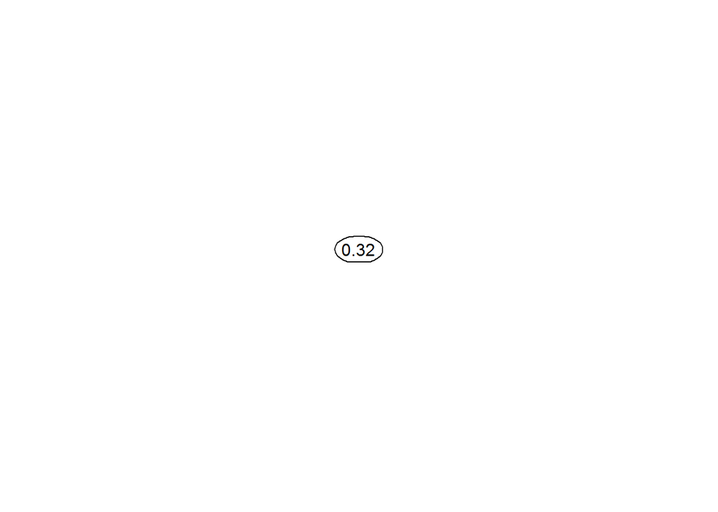

```r
CARTmodel = rpart(voting~hawthorne+civicduty+self+neighbors, data=gerber) #exclude "method='class'"
#when building regression tree
prp(CARTmodel)
```

All we see in the regression tree above is a single leaf node with the value 0.32; this implies that none of the 4 variables are significant enough to split on. This contradicts the output of the logistic regression in Problem 1, which indicated that all 4 variables are very significant.

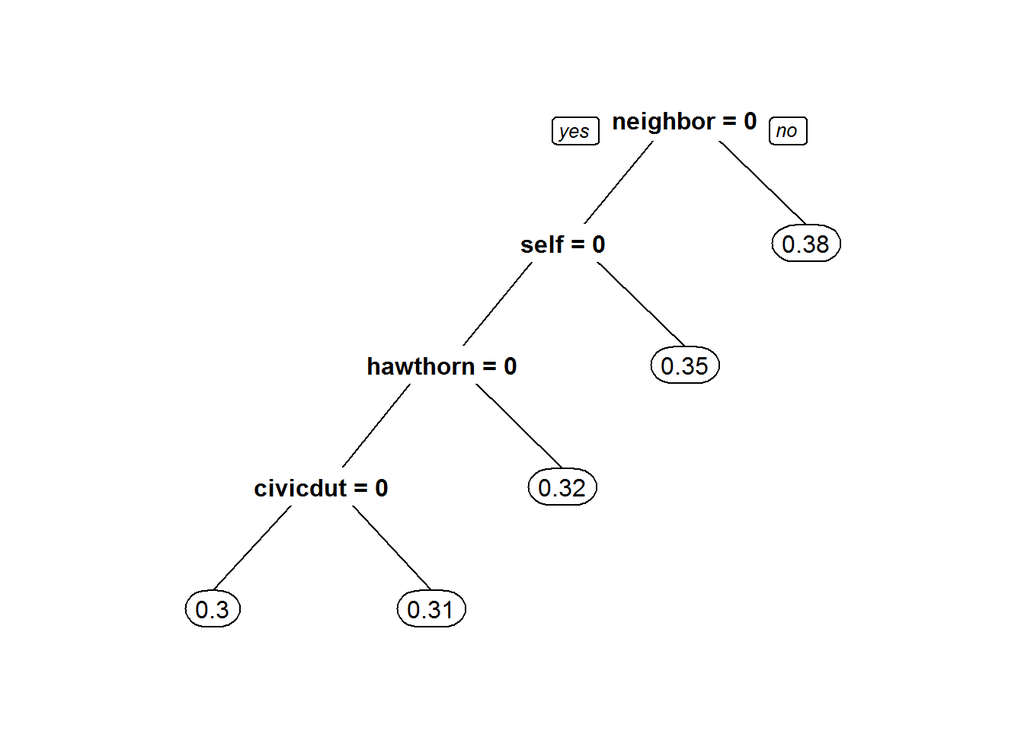

```r
CARTmodel2 = rpart(voting~hawthorne+civicduty+self+neighbors, data=gerber, cp=0.0) #cp = 0.0 forces model to be built
prp(CARTmodel2)
```

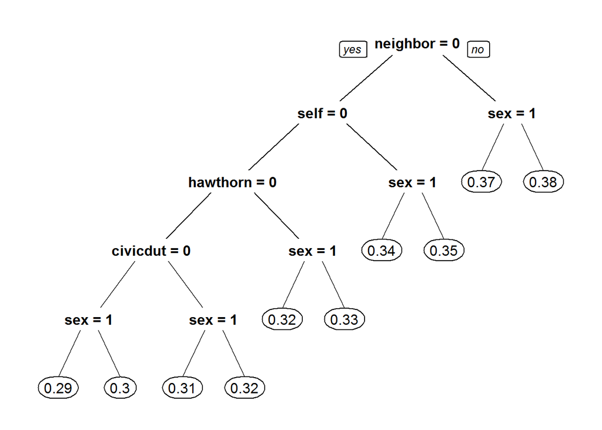

```r
CARTmodel3 = rpart(voting ~ civicduty + hawthorne + self + neighbors + sex, data=gerber, cp=0.0)
prp(CARTmodel3)
```

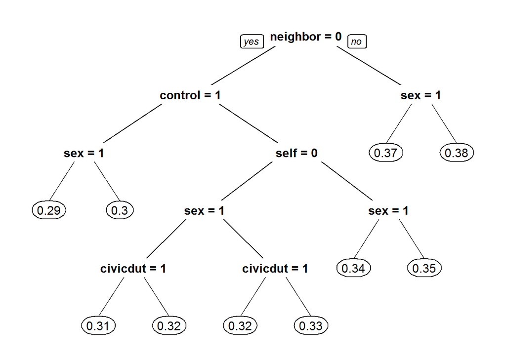

```r
CARTmodel3_another = rpart(voting~civicduty + hawthorne + self +neighbors + control +sex, data = gerber, cp = 0.0)
prp(CARTmodel3_another)
```

Notice how we get a different looking tree when the variable ‘control’ is explicitly included in the model. However, notice that the probabilities of voting for males and females receiving the ‘civicduty’ notice are the same as they are in the tree without the ‘control’ variable explicitly included.

### Problem 3

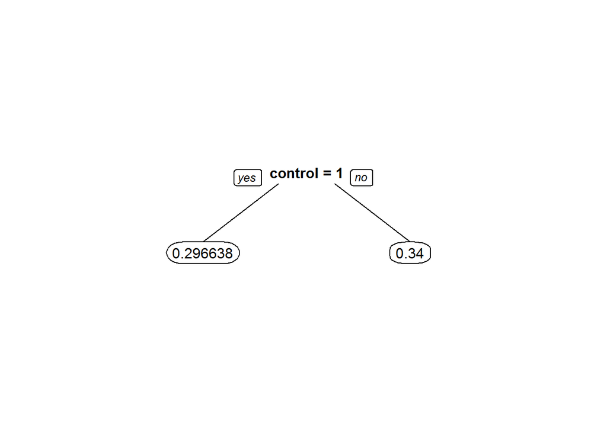

```r
controlRegrTree = rpart(voting~control, data=gerber, cp=0.0)
prp(controlRegrTree, digits=6)
```

```r
controlRegrTreeVals=predict(controlRegrTree)%>%unique()
abs(controlRegrTreeVals[1]-controlRegrTreeVals[2])
```

```
## [1] 0.04336208
```

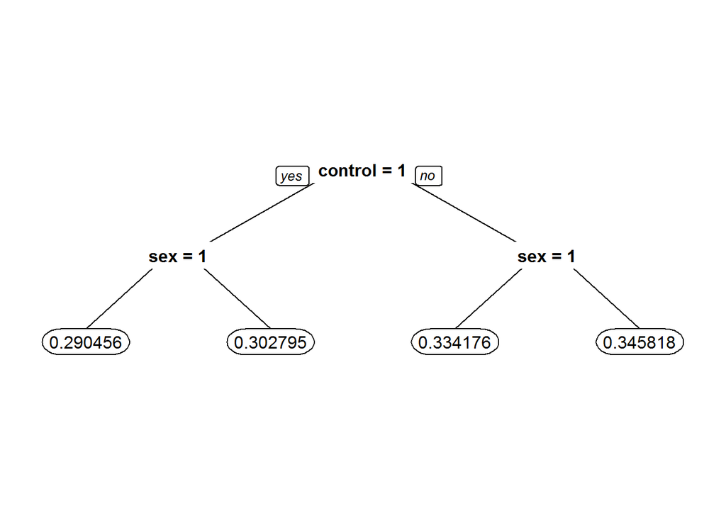

```r
controlSexRegrTree = rpart(voting~control+sex, data=gerber, cp=0.0)
prp(controlSexRegrTree, digits = 6)
```

```r
controlSexRegrTreeVals = predict(controlSexRegrTree)%>%unique()
maleDiffs = controlSexRegrTreeVals[1] - controlSexRegrTreeVals[4]
femaleDiffs = controlSexRegrTreeVals[2] - controlSexRegrTreeVals[3]
abs(maleDiffs-femaleDiffs)
```

```
## [1] 0.0006962367
```

```r
voting_sexControl_logregr = glm(voting~sex+control, data=gerber, family='binomial')
summary(voting_sexControl_logregr)
```

```
##
## Call:
## glm(formula = voting ~ sex + control, family = "binomial", data = gerber)
##
## Deviance Residuals:
##     Min       1Q   Median       3Q      Max
## -0.9220  -0.9012  -0.8290   1.4564   1.5717
##
## Coefficients:
##              Estimate Std. Error z value Pr(>|z|)
## (Intercept) -0.635538   0.006511 -97.616  < 2e-16 ***
## sex         -0.055791   0.007343  -7.597 3.02e-14 ***
## control     -0.200142   0.007364 -27.179  < 2e-16 ***
## ---
## Signif. codes:  0 '***' 0.001 '**' 0.01 '*' 0.05 '.' 0.1 ' ' 1
##
## (Dispersion parameter for binomial family taken to be 1)
##
##     Null deviance: 429238  on 344083  degrees of freedom
## Residual deviance: 428443  on 344081  degrees of freedom
## AIC: 428449
##
## Number of Fisher Scoring iterations: 4
```

```r
doubles = data.frame(sex=c(0,0,1,1), control=c(0,1,0,1))
logRegPreds = predict(voting_sexControl_logregr, doubles, type='response')
logRegPreds
```

```
##         1         2         3         4
## 0.3462559 0.3024455 0.3337375 0.2908065
```

```r
LogModel2 = glm(voting ~ sex + control + sex:control, data=gerber, family="binomial")
LogModel2%>%summary
```

```
##
## Call:
## glm(formula = voting ~ sex + control + sex:control, family = "binomial",
##     data = gerber)
##
## Deviance Residuals:
##     Min       1Q   Median       3Q      Max
## -0.9213  -0.9019  -0.8284   1.4573   1.5724
##
## Coefficients:
##              Estimate Std. Error z value Pr(>|z|)
## (Intercept) -0.637471   0.007603 -83.843  < 2e-16 ***
## sex         -0.051888   0.010801  -4.804 1.55e-06 ***
## control     -0.196553   0.010356 -18.980  < 2e-16 ***
## sex:control -0.007259   0.014729  -0.493    0.622
## ---
## Signif. codes:  0 '***' 0.001 '**' 0.01 '*' 0.05 '.' 0.1 ' ' 1
##
## (Dispersion parameter for binomial family taken to be 1)
##
##     Null deviance: 429238  on 344083  degrees of freedom
## Residual deviance: 428442  on 344080  degrees of freedom
## AIC: 428450
##
## Number of Fisher Scoring iterations: 4
```

```r
predict(LogModel2, doubles, type='response')
```

```
##         1         2         3         4
## 0.3458183 0.3027947 0.3341757 0.2904558
```

Take-home msg: a regression tree can capture a non-linear relationship between predictors and the response because it implicitly considers interactions as you proceed down the tree (for e.g. interaction between sex and control on voting in this dataset).

NOTE: Reminder, overfitting is more of a problem with small datasets.

## Letter Prediction Dataset

Reminder on random forests: The random forest method involves building a bunch of CART trees from the data. Each CART tree consists of subset of the variables and a bootstrapped sample (with replacement) of the observations. The trees then ‘vote’ on the outcome and the outcome that receives the majority of the votes is chosen. Random Forests in R involve the nodesize parameter, which is similar to the minBucket parameter in R. The smaller the nodesize, the more complicated the forest. The nTree parameter specifies the number of trees. The random forest method is not as sensitive to parameter values as is CART. When using random forests to do classification, the response variable must be a factor.

### Problem 1

```r
letters = read.csv('letters_ABPR.csv')
letters$isB = as.factor(letters$letter == "B")
set.seed(1000)
split = sample.split(letters$isB, SplitRatio=0.50)
train = subset(letters, split)
test = subset(letters, !split)
summary(letters)
```

```
##  letter       xbox             ybox            width
##  A:789   Min.   : 0.000   Min.   : 0.000   Min.   : 1.000
##  B:766   1st Qu.: 3.000   1st Qu.: 5.000   1st Qu.: 4.000
##  P:803   Median : 4.000   Median : 7.000   Median : 5.000
##  R:758   Mean   : 3.915   Mean   : 7.051   Mean   : 5.186
##          3rd Qu.: 5.000   3rd Qu.: 9.000   3rd Qu.: 6.000
##          Max.   :13.000   Max.   :15.000   Max.   :11.000
##      height           onpix             xbar             ybar
##  Min.   : 0.000   Min.   : 0.000   Min.   : 3.000   Min.   : 0.000
##  1st Qu.: 4.000   1st Qu.: 2.000   1st Qu.: 6.000   1st Qu.: 6.000
##  Median : 6.000   Median : 4.000   Median : 7.000   Median : 7.000
##  Mean   : 5.276   Mean   : 3.869   Mean   : 7.469   Mean   : 7.197
##  3rd Qu.: 7.000   3rd Qu.: 5.000   3rd Qu.: 8.000   3rd Qu.: 9.000
##  Max.   :12.000   Max.   :12.000   Max.   :14.000   Max.   :15.000
##      x2bar            y2bar           xybar            x2ybar
##  Min.   : 0.000   Min.   :0.000   Min.   : 3.000   Min.   : 0.00
##  1st Qu.: 3.000   1st Qu.:2.000   1st Qu.: 7.000   1st Qu.: 3.00
##  Median : 4.000   Median :4.000   Median : 8.000   Median : 5.00
##  Mean   : 4.706   Mean   :3.903   Mean   : 8.491   Mean   : 4.52
##  3rd Qu.: 6.000   3rd Qu.:5.000   3rd Qu.:10.000   3rd Qu.: 6.00
##  Max.   :11.000   Max.   :8.000   Max.   :14.000   Max.   :10.00
##      xy2bar           xedge          xedgeycor          yedge
##  Min.   : 0.000   Min.   : 0.000   Min.   : 1.000   Min.   : 0.0
##  1st Qu.: 6.000   1st Qu.: 2.000   1st Qu.: 7.000   1st Qu.: 3.0
##  Median : 7.000   Median : 2.000   Median : 8.000   Median : 4.0
##  Mean   : 6.711   Mean   : 2.913   Mean   : 7.763   Mean   : 4.6
##  3rd Qu.: 8.000   3rd Qu.: 4.000   3rd Qu.: 9.000   3rd Qu.: 6.0
##  Max.   :14.000   Max.   :10.000   Max.   :13.000   Max.   :12.0
##    yedgexcor         isB
##  Min.   : 1.000   FALSE:2350
##  1st Qu.: 7.000   TRUE : 766
##  Median : 8.000
##  Mean   : 8.418
##  3rd Qu.:10.000
##  Max.   :13.000
```

```r
isB_classificationTree = rpart(isB ~ .-letter, data = train, method="class")
isB_testTable = table(test$isB, predict(isB_classificationTree, newdata=test, type='class'))
isB_testTable
```

```
##
##         FALSE TRUE
##   FALSE  1118   57
##   TRUE     43  340
```

```r
set.seed(1000)
isB_classificationForest = randomForest(isB ~ .-letter, data=train)
table(test$isB, predict(isB_classificationForest,newdata=test, type='class'))
```

```
##
##         FALSE TRUE
##   FALSE  1163   12
##   TRUE      9  374
```

NOTE: when constructing isB_classificationForest (in code chunk above), the parameters nTtree and nodesize parameters, and R sets them to their default values (500 for ntree and either 5 or 1 for nodesize).

### Problem 2

```r
set.seed(2000)
split=sample.split(letters$letter, SplitRatio =0.50)
train = subset(letters, split)
test = subset(letters, !split)
table(train$letter)
```

```
##
##   A   B   P   R
## 394 383 402 379
```

```r
table(test$letter)
```

```
##
##   A   B   P   R
## 395 383 401 379
```

```r
CARTmodel = rpart(letter ~ .-isB, data=train, method='class')
cartTbl=table(test$letter, predict(CARTmodel, newdata=test, type='class'))
computeDiag=function(t){
  tot=0
  for (i in seq(nrow(t))){
    tot = tot+t[i,i]
  }
  return(tot)
}
computeDiag(cartTbl)/sum(cartTbl)
```

```
## [1] 0.8786906
```

```r
set.seed(1000)
randomForestModel = randomForest(letter ~ .-isB, data=train)
randomForestTbl=table(test$letter, predict(randomForestModel, newdata=test, type='class'))
computeDiag(randomForestTbl)/sum(randomForestTbl)
```

```
## [1] 0.9801027
```

## Census Dataset for salary classification

### Problem 1

```r
census=read.csv("census.csv")
set.seed(2000)
split = sample.split(census$over50k, SplitRatio = 0.60)
train = subset(census, split)
test = subset(census, !split)
logRegrMod = glm(over50k ~ ., data=train, family='binomial')
summary(logRegrMod)
```

```
##
## Call:
## glm(formula = over50k ~ ., family = "binomial", data = train)
##
## Deviance Residuals:
##     Min       1Q   Median       3Q      Max
## -5.1065  -0.5037  -0.1804  -0.0008   3.3383
##
## Coefficients: (1 not defined because of singularities)
##                                            Estimate Std. Error z value
## (Intercept)                              -8.658e+00  1.379e+00  -6.279
## age                                       2.548e-02  2.139e-03  11.916
## workclass Federal-gov                     1.105e+00  2.014e-01   5.489
## workclass Local-gov                       3.675e-01  1.821e-01   2.018
## workclass Never-worked                   -1.283e+01  8.453e+02  -0.015
## workclass Private                         6.012e-01  1.626e-01   3.698
## workclass Self-emp-inc                    7.575e-01  1.950e-01   3.884
## workclass Self-emp-not-inc                1.855e-01  1.774e-01   1.046
## workclass State-gov                       4.012e-01  1.961e-01   2.046
## workclass Without-pay                    -1.395e+01  6.597e+02  -0.021
## education 11th                            2.225e-01  2.867e-01   0.776
## education 12th                            6.380e-01  3.597e-01   1.774
## education 1st-4th                        -7.075e-01  7.760e-01  -0.912
## education 5th-6th                        -3.170e-01  4.880e-01  -0.650
## education 7th-8th                        -3.498e-01  3.126e-01  -1.119
## education 9th                            -1.258e-01  3.539e-01  -0.355
## education Assoc-acdm                      1.602e+00  2.427e-01   6.601
## education Assoc-voc                       1.541e+00  2.368e-01   6.506
## education Bachelors                       2.177e+00  2.218e-01   9.817
## education Doctorate                       2.761e+00  2.893e-01   9.544
## education HS-grad                         1.006e+00  2.169e-01   4.638
## education Masters                         2.421e+00  2.353e-01  10.289
## education Preschool                      -2.237e+01  6.864e+02  -0.033
## education Prof-school                     2.938e+00  2.753e-01  10.672
## education Some-college                    1.365e+00  2.195e-01   6.219
## maritalstatus Married-AF-spouse           2.540e+00  7.145e-01   3.555
## maritalstatus Married-civ-spouse          2.458e+00  3.573e-01   6.880
## maritalstatus Married-spouse-absent      -9.486e-02  3.204e-01  -0.296
## maritalstatus Never-married              -4.515e-01  1.139e-01  -3.962
## maritalstatus Separated                   3.609e-02  1.984e-01   0.182
```

[output cut: 162 more lines]

```
## nativecountry Thailand                   0.329678
## nativecountry Trinadad&Tobago            0.434105
## nativecountry United-States              0.946020
## nativecountry Vietnam                    0.507799
## nativecountry Yugoslavia                 0.394874
## ---
## Signif. codes:  0 '***' 0.001 '**' 0.01 '*' 0.05 '.' 0.1 ' ' 1
##
## (Dispersion parameter for binomial family taken to be 1)
##
##     Null deviance: 21175  on 19186  degrees of freedom
## Residual deviance: 12104  on 19090  degrees of freedom
## AIC: 12298
##
## Number of Fisher Scoring iterations: 15
```

```r
table(test$over50k, predict(logRegrMod, newdata=test, type='response')>=0.50)
```

```
##
##          FALSE TRUE
##    <=50K  9051  662
##    >50K   1190 1888
```

```r
logRegrModPredictionObj = prediction(predict(logRegrMod, newdata=test, type='response'), test$over50k)
performance(logRegrModPredictionObj, "auc")@y.values%>%as.numeric
```

```
## [1] 0.9061598
```

### Problem 2

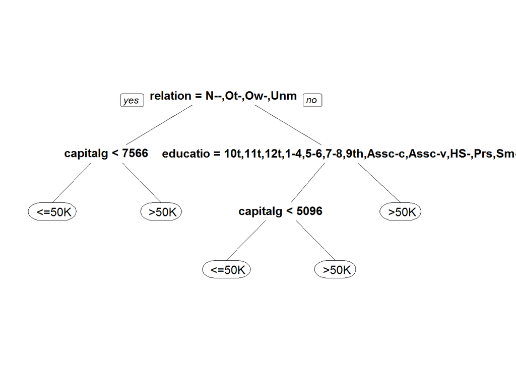

```r
censusClassTree = rpart(over50k ~ ., data=train, method="class")
prp(censusClassTree)
```

```r
#predict(censusClassTree, newdata=test)%>%str #Note: if you leave out
#"type='response'", you'll get a vector of probabilities
table(test$over50k, predict(censusClassTree, newdata=test,type='class'))
```

```
##
##           <=50K  >50K
##    <=50K   9243   470
##    >50K    1482  1596
```

Note that when calling the predict() function, leaving out the “type=‘class’” will give a matrix of probability vectors- one probability vector for each level of the response variable (see the first five rows of the matrix outputted below).

```r
probabilities = predict(censusClassTree, newdata=test)
probabilities[1:5,]
```

```
##        <=50K       >50K
## 2  0.2794982 0.72050176
## 5  0.2794982 0.72050176
## 7  0.9490143 0.05098572
## 8  0.6972807 0.30271934
## 11 0.6972807 0.30271934
```

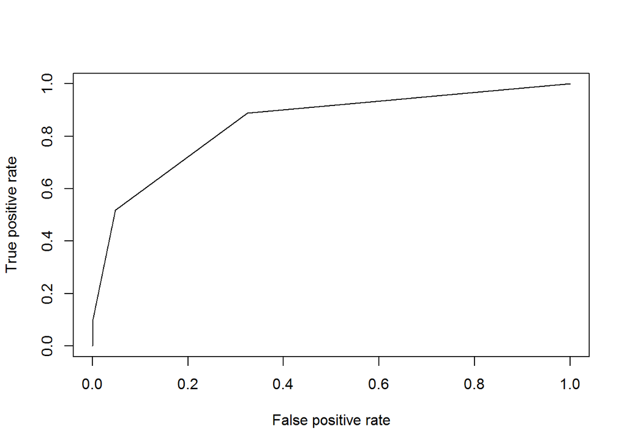

```r
over50k = probabilities[,2]
censusCARTpredictionObj = prediction(over50k, test$over50k)
censusClassTree_ROC = performance(censusCARTpredictionObj, "tpr", "fpr")
plot(censusClassTree_ROC)
```

```r
as.numeric(performance(censusCARTpredictionObj,"auc")@y.values)
```

```
## [1] 0.8470256
```

### Problem 3 (NOTE: my answer to problem 3.1 differs from the official answer. May be due to my operating system handling the sampling and random forest functions differently from the TA’s operating system.)

```r
set.seed(1)
trainSmall = train[sample(nrow(train), 2000), ]
set.seed(1)
censusrf = randomForest(over50k ~ . , data = trainSmall)
predictTest = predict(censusrf, newdata=test)
table(test$over50k, predictTest)
```

```
##         predictTest
##           <=50K  >50K
##    <=50K   8843   870
##    >50K    1029  2049
```

Below code chunk displays plot that indicates the number of times each variable was selected for in a split (aggregated over all trees in the model) in the building of the random forest model.

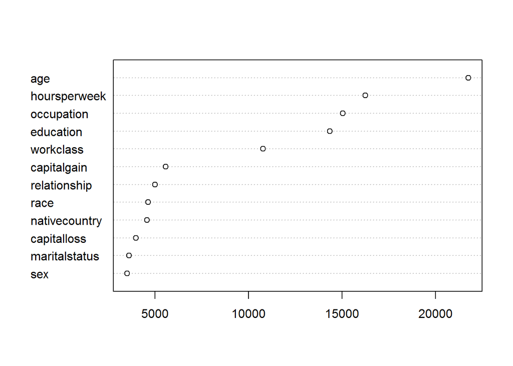

```r
vu = varUsed(censusrf, count=TRUE)
vusorted = sort(vu, decreasing = FALSE, index.return = TRUE)
dotchart(vusorted$x, names(censusrf$forest$xlevels[vusorted$ix]))
```

Below code chunk plots the mean reduction impurity for each variable. Any time a split is performed on a particular variable, the impurity of the observations remaining after the split is decreased. The mean reduction in impurity for a variable is the reduction in impurity for that variable averaged over all of the times that that variable is selected for in a split for all trees in the forest.

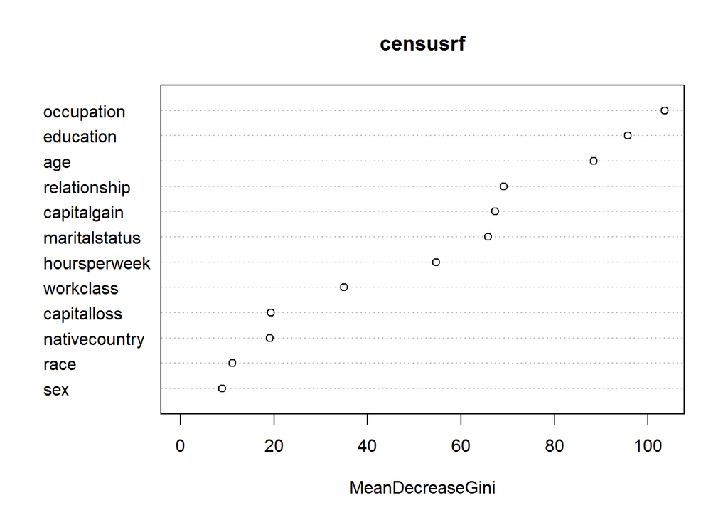

```r
varImpPlot(censusrf)
```

### Problem 4

*Reminder on how to determine best value of cp for CART model:* 1. create trainControl and expand.grid objects 2. call train() function, passing in trainControl object as trControl parameter and expand.grid object as tuneGrid parameter

```r
set.seed(2)
tr.control=trainControl(method="cv", number=10)
cp.grid =expand.grid(.cp=seq(0.002,0.1,0.002))
train(over50k~.,data=train,method="rpart",trControl=tr.control,tuneGrid=cp.grid)
```

```
## CART
##
## 19187 samples
##    12 predictor
##     2 classes: ' <=50K', ' >50K'
##
## No pre-processing
## Resampling: Cross-Validated (10 fold)
## Summary of sample sizes: 17268, 17268, 17269, 17269, 17269, 17268, ...
## Resampling results across tuning parameters:
##
##   cp     Accuracy   Kappa
##   0.002  0.8510972  0.55404931
##   0.004  0.8482829  0.55537475
##   0.006  0.8452078  0.53914084
##   0.008  0.8442176  0.53817486
##   0.010  0.8433317  0.53305978
##   0.012  0.8433317  0.53305978
##   0.014  0.8433317  0.53305978
##   0.016  0.8413510  0.52349296
##   0.018  0.8400480  0.51528594
##   0.020  0.8381193  0.50351272
##   0.022  0.8381193  0.50351272
##   0.024  0.8381193  0.50351272
##   0.026  0.8381193  0.50351272
##   0.028  0.8381193  0.50351272
##   0.030  0.8381193  0.50351272
##   0.032  0.8381193  0.50351272
##   0.034  0.8352011  0.48749911
##   0.036  0.8326470  0.47340390
##   0.038  0.8267570  0.44688035
##   0.040  0.8248289  0.43893150
##   0.042  0.8248289  0.43893150
##   0.044  0.8248289  0.43893150
##   0.046  0.8248289  0.43893150
##   0.048  0.8248289  0.43893150
##   0.050  0.8231084  0.42467058
##   0.052  0.8174798  0.37478096
##   0.054  0.8138837  0.33679015
##   0.056  0.8118514  0.30751485
```

[output cut: 10 more lines]

```
##   0.078  0.7593684  0.00000000
##   0.080  0.7593684  0.00000000
##   0.082  0.7593684  0.00000000
##   0.084  0.7593684  0.00000000
##   0.086  0.7593684  0.00000000
##   0.088  0.7593684  0.00000000
##   0.090  0.7593684  0.00000000
##   0.092  0.7593684  0.00000000
##   0.094  0.7593684  0.00000000
##   0.096  0.7593684  0.00000000
##   0.098  0.7593684  0.00000000
##   0.100  0.7593684  0.00000000
##
## Accuracy was used to select the optimal model using the largest value.
## The final value used for the model was cp = 0.002.
```

```r
CARTmodel_best_cp = rpart(over50k~., data=train, method="class", cp=0.002)
table(test$over50k, predict(CARTmodel_best_cp, newdata=test, type="class"))
```

```
##
##           <=50K  >50K
##    <=50K   9178   535
##    >50K    1240  1838
```

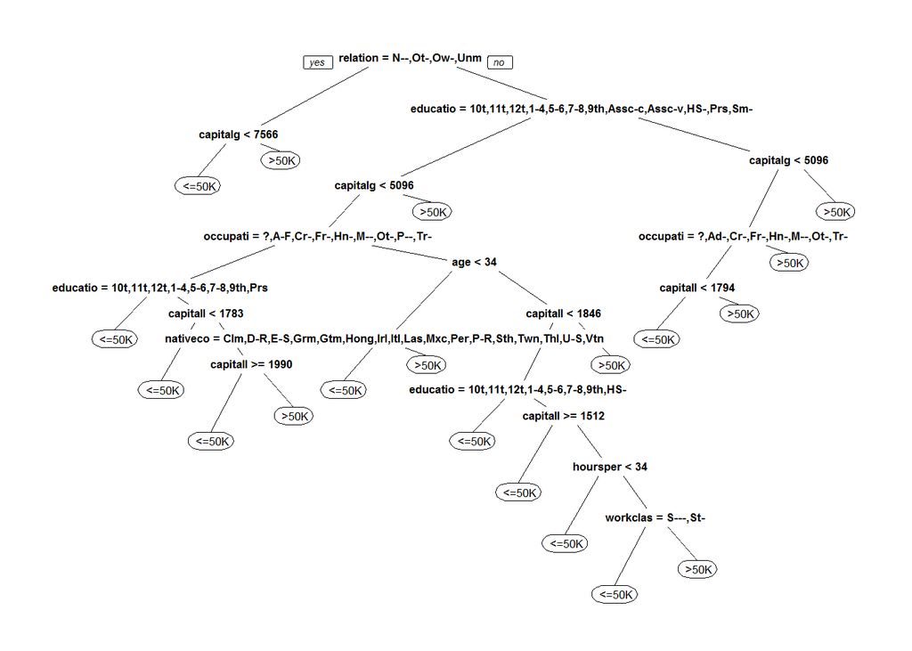

```r
prp(CARTmodel_best_cp)
```

## States revisited

```r
states= read.csv('statedataSimple.csv')
head(states)
```

```
##   Population Income Illiteracy Life.Exp Murder HS.Grad Frost   Area
## 1       3615   3624        2.1    69.05   15.1    41.3    20  50708
## 2        365   6315        1.5    69.31   11.3    66.7   152 566432
## 3       2212   4530        1.8    70.55    7.8    58.1    15 113417
## 4       2110   3378        1.9    70.66   10.1    39.9    65  51945
## 5      21198   5114        1.1    71.71   10.3    62.6    20 156361
## 6       2541   4884        0.7    72.06    6.8    63.9   166 103766
```

### Problem 1

```r
fullLinMod = lm(Life.Exp~., data=states)
summary(fullLinMod)
```

```
##
## Call:
## lm(formula = Life.Exp ~ ., data = states)
##
## Residuals:
##      Min       1Q   Median       3Q      Max
## -1.48895 -0.51232 -0.02747  0.57002  1.49447
##
## Coefficients:
##               Estimate Std. Error t value Pr(>|t|)
## (Intercept)  7.094e+01  1.748e+00  40.586  < 2e-16 ***
## Population   5.180e-05  2.919e-05   1.775   0.0832 .
## Income      -2.180e-05  2.444e-04  -0.089   0.9293
## Illiteracy   3.382e-02  3.663e-01   0.092   0.9269
## Murder      -3.011e-01  4.662e-02  -6.459 8.68e-08 ***
## HS.Grad      4.893e-02  2.332e-02   2.098   0.0420 *
## Frost       -5.735e-03  3.143e-03  -1.825   0.0752 .
## Area        -7.383e-08  1.668e-06  -0.044   0.9649
## ---
## Signif. codes:  0 '***' 0.001 '**' 0.01 '*' 0.05 '.' 0.1 ' ' 1
##
## Residual standard error: 0.7448 on 42 degrees of freedom
## Multiple R-squared:  0.7362, Adjusted R-squared:  0.6922
## F-statistic: 16.74 on 7 and 42 DF,  p-value: 2.534e-10
```

```r
sum((fullLinMod$residuals)^2)
```

```
## [1] 23.29714
```

*Note that confusion matrices and areas under ROC curves (AUC) are used to gauge the accuracy of classification models (categorical response var) while sum of squared errors (SSEs) are used to gauge the accuracy of regression models (numeric response var).*

```r
signifAndAlmostSignifLinMod = lm(Life.Exp~Population+ Murder+Frost+HS.Grad, data=states)
summary(signifAndAlmostSignifLinMod)
```

```
##
## Call:
## lm(formula = Life.Exp ~ Population + Murder + Frost + HS.Grad,
##     data = states)
##
## Residuals:
##      Min       1Q   Median       3Q      Max
## -1.47095 -0.53464 -0.03701  0.57621  1.50683
##
## Coefficients:
##               Estimate Std. Error t value Pr(>|t|)
## (Intercept)  7.103e+01  9.529e-01  74.542  < 2e-16 ***
## Population   5.014e-05  2.512e-05   1.996  0.05201 .
## Murder      -3.001e-01  3.661e-02  -8.199 1.77e-10 ***
## Frost       -5.943e-03  2.421e-03  -2.455  0.01802 *
## HS.Grad      4.658e-02  1.483e-02   3.142  0.00297 **
## ---
## Signif. codes:  0 '***' 0.001 '**' 0.01 '*' 0.05 '.' 0.1 ' ' 1
##
## Residual standard error: 0.7197 on 45 degrees of freedom
## Multiple R-squared:  0.736,  Adjusted R-squared:  0.7126
## F-statistic: 31.37 on 4 and 45 DF,  p-value: 1.696e-12
```

```r
sum((signifAndAlmostSignifLinMod$residuals)^2)
```

```
## [1] 23.30804
```

### Problem 2

*Note: For the rpart function, minbucket is by default set to 7 if no minsplit is specified or if a minsplit is specified, minbucket is set to round(minsplit/3). cp is by default set to 0.01*

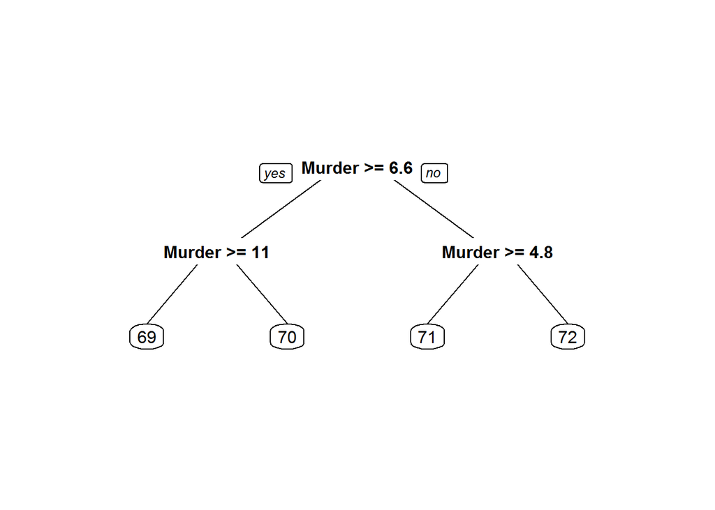

```r
FullCART = rpart(Life.Exp~., data=states)
prp(FullCART)
```

Murder is the only variable that shows up in the full tree.

```r
cor(states)[4,]
```

```
##  Population      Income  Illiteracy    Life.Exp      Murder     HS.Grad
## -0.06805195  0.34025534 -0.58847793  1.00000000 -0.78084575  0.58221620
##       Frost        Area
##  0.26206801 -0.10733194
```

That murder shows up as a variable falls in line with intuition, as Murder has the highest correlation with Life.Exp.

```r
FullCARTPreds = predict(FullCART)
sum((FullCARTPreds - states$Life.Exp)^2)
```

```
## [1] 28.99848
```

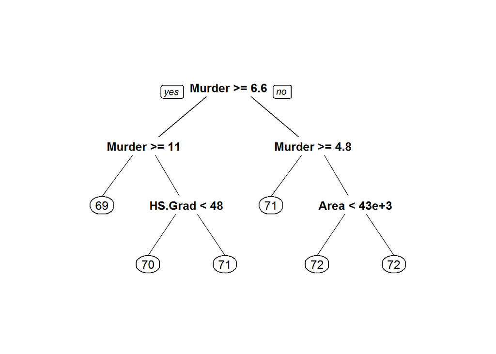

```r
FullCARTLowerMinbucket = rpart(Life.Exp~., data=states, minbucket=5)
prp(FullCARTLowerMinbucket)
```

```r
FullCARTLowerMinbucketPreds = predict(FullCARTLowerMinbucket)
sum((FullCARTLowerMinbucketPreds - states$Life.Exp)^2)
```

```
## [1] 23.64283
```

So the SSE dropped significantly by just lowering the minbucket and this CART model’s SSE is almost as low as those of the linear models above. In addition to Murder, both HS.Grad and Area make an appearance in the regression tree for this CART model.

How about lowering minbucket to 1? (*Note: this isn’t explicitly in the homework*)

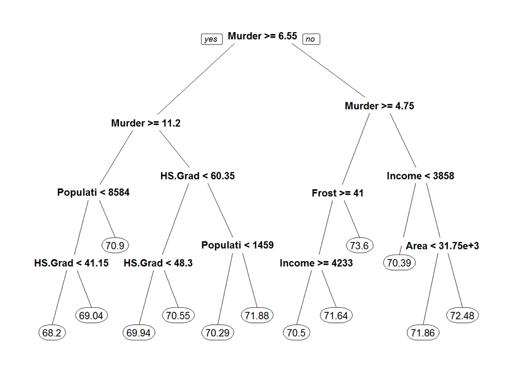

```r
FullCARTSmallestMinbucket = rpart(Life.Exp~., data=states, minbucket=1)
prp(FullCARTSmallestMinbucket, digits=4)
```

```r
FullCARTSmallestMinbucketPreds = predict(FullCARTSmallestMinbucket)
sum((FullCARTSmallestMinbucketPreds - states$Life.Exp)^2)
```

```
## [1] 4.944288
```

The SSE is shockingly low at 4.94! However, the tree is a bit more complicated than desired.

By some incredible feat of imagination let’s say we guessed that the area of a state would have a huge influence on its life expectancy; then we could try to build a regression tree using only Area (both with and without minbucket=1)

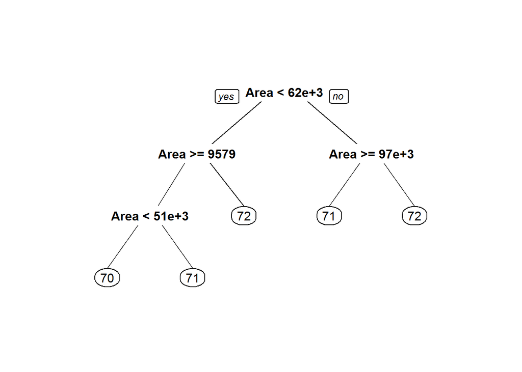

```r
onlyAreaCART = rpart(Life.Exp~Area, data=states)
prp(onlyAreaCART)
```

```r
onlyAreaCARTPreds = predict(onlyAreaCART)
sum((states$Life.Exp - onlyAreaCARTPreds)^2)
```

```
## [1] 44.26817
```

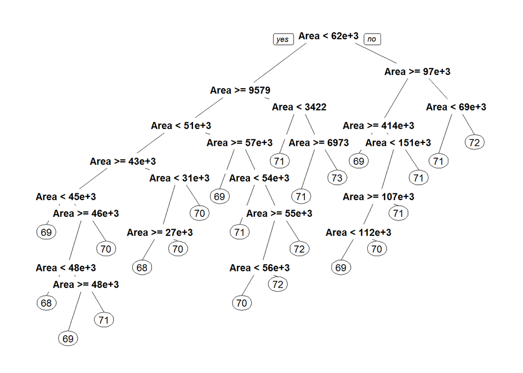

```r
onlyAreaCARTSmallestMinbucket = rpart(Life.Exp~Area, data=states, minbucket=1)
prp(onlyAreaCARTSmallestMinbucket)
```

```r
onlyAreaCARTSmallestMinbucketPreds = predict(onlyAreaCARTSmallestMinbucket)
sum((states$Life.Exp - onlyAreaCARTSmallestMinbucketPreds)^2)
```

```
## [1] 9.312442
```

Both CART trees using just Area are pretty complicated, but the one with minbucket=1 is easily the more complicated. The SSE for the tree with the default minbucket is pretty bad (over 40), but the one for the tree with the minbucket of 1 is really good at 9.31. However, the CART tree with minbucket of 1 and all the variables is both far more interpretable and more accurate (SSE of 4.94) than the CART tree with just Area and minbucket of 1.

### Problem 3

Demonstrates picking the optimal cp value and using that value as a parameter to rpart().

```r
set.seed(111)
tr.control=trainControl(method="cv", number=10)
cp.grid =expand.grid(.cp=seq(0.01,0.5,0.01))
train(Life.Exp~.,data=states,method="rpart",trControl=tr.control,tuneGrid=cp.grid)
```

```
## CART
##
## 50 samples
##  7 predictor
##
## No pre-processing
## Resampling: Cross-Validated (10 fold)
## Summary of sample sizes: 46, 45, 44, 43, 46, 46, ...
## Resampling results across tuning parameters:
##
##   cp    RMSE       Rsquared   MAE
##   0.01  1.1375138  0.4734757  0.9362281
##   0.02  1.1375138  0.4734757  0.9362281
##   0.03  1.1375138  0.4734757  0.9362281
##   0.04  1.1231367  0.4734757  0.9286572
##   0.05  1.0817092  0.4923520  0.8907357
##   0.06  1.0709561  0.4923520  0.8822194
##   0.07  1.0149896  0.5275358  0.8371557
##   0.08  0.9933235  0.5436269  0.8117516
##   0.09  0.9933235  0.5436269  0.8117516
##   0.10  0.9933235  0.5436269  0.8117516
##   0.11  0.9933235  0.5436269  0.8117516
##   0.12  0.9933235  0.5436269  0.8117516
##   0.13  1.0568377  0.4988101  0.8515894
##   0.14  1.1221457  0.4758470  0.8944743
##   0.15  1.1399888  0.4642198  0.9140933
##   0.16  1.1244999  0.4642198  0.8983067
##   0.17  1.1244999  0.4642198  0.8983067
##   0.18  1.1463316  0.4642198  0.9112852
##   0.19  1.1463316  0.4642198  0.9112852
##   0.20  1.1463316  0.4642198  0.9112852
##   0.21  1.1463316  0.4642198  0.9112852
##   0.22  1.1636884  0.4527311  0.9468219
##   0.23  1.1636884  0.4527311  0.9468219
##   0.24  1.1636884  0.4527311  0.9468219
##   0.25  1.1636884  0.4527311  0.9468219
##   0.26  1.1636884  0.4527311  0.9468219
##   0.27  1.1636884  0.4527311  0.9468219
##   0.28  1.1636884  0.4527311  0.9468219
##   0.29  1.1636884  0.4527311  0.9468219
```

[output cut: 9 more lines]

```
##   0.39  1.1636884  0.4527311  0.9468219
##   0.40  1.1636884  0.4527311  0.9468219
##   0.41  1.1636884  0.4527311  0.9468219
##   0.42  1.1636884  0.4527311  0.9468219
##   0.43  1.1636884  0.4527311  0.9468219
##   0.44  1.1636884  0.4527311  0.9468219
##   0.45  1.1636884  0.4527311  0.9468219
##   0.46  1.2203897  0.4201907  0.9944414
##   0.47  1.3782050  0.2554142  1.1446881
##   0.48  1.4203510  0.1945662  1.1636157
##   0.49  1.4376198  0.1194860  1.1863268
##   0.50  1.4402764  0.1194860  1.1910118
##
## RMSE was used to select the optimal model using the smallest value.
## The final value used for the model was cp = 0.12.
```

Optimal value is highest cp value with lowest RMSE when there are cp values with tied RMSEs. Higher cp values mean simpler trees.

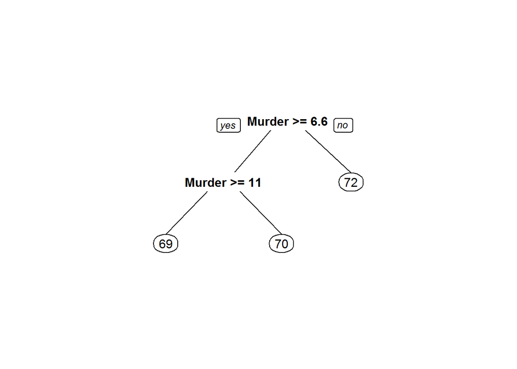

```r
tunedCARTmodel = rpart(Life.Exp~., data=states, cp=0.12)
prp(tunedCARTmodel)
```

```r
tunedCARTmodelPreds = predict(tunedCARTmodel)
sum((tunedCARTmodelPreds-states$Life.Exp)^2)
```

```
## [1] 32.86549
```

Oddly enough, the tuned rpart() model has a higher SSE than the original model with the defaults (its SSE was 28.99848). However, NOTE that these SSEs were all calculated by testing on the ORIGINAL data, so an overfit model will do better on the original data. We’d still expect the tuned CART model to perform better on out-of-sample test data (even though its SSE is higher than that for the default CART model on in-sample data).

We’ll now perform a tuned CART using ONLY Area as the predictor and see how the model performs relative to the others.

```r
set.seed(111)
tr.control=trainControl(method="cv", number=10)
cp.grid =expand.grid(.cp=seq(0.01,0.5,0.01))
train(Life.Exp~Area,data=states,method="rpart",trControl=tr.control,tuneGrid=cp.grid)
```

```
## CART
##
## 50 samples
##  1 predictor
##
## No pre-processing
## Resampling: Cross-Validated (10 fold)
## Summary of sample sizes: 46, 45, 44, 43, 46, 46, ...
## Resampling results across tuning parameters:
##
##   cp    RMSE      Rsquared    MAE
##   0.01  1.231586  0.39845523  1.006585
##   0.02  1.243748  0.38909431  1.016449
##   0.03  1.243748  0.38909431  1.016449
##   0.04  1.246020  0.38659302  1.020503
##   0.05  1.246020  0.38659302  1.020503
##   0.06  1.257693  0.38542329  1.028342
##   0.07  1.284635  0.37765344  1.063739
##   0.08  1.295051  0.36309730  1.080484
##   0.09  1.295051  0.36309730  1.080484
##   0.10  1.295051  0.36309730  1.080484
##   0.11  1.393421  0.26634509  1.155116
##   0.12  1.393421  0.26634509  1.155116
##   0.13  1.393421  0.26634509  1.155116
##   0.14  1.408479  0.20191108  1.177991
##   0.15  1.391087  0.23690897  1.190359
##   0.16  1.391087  0.23690897  1.190359
##   0.17  1.368303  0.08957212  1.147769
##   0.18  1.369533  0.01795209  1.142731
##   0.19  1.356254  0.01795209  1.131768
##   0.20  1.328025         NaN  1.094530
##   0.21  1.328025         NaN  1.094530
##   0.22  1.328025         NaN  1.094530
##   0.23  1.328025         NaN  1.094530
##   0.24  1.328025         NaN  1.094530
##   0.25  1.328025         NaN  1.094530
##   0.26  1.328025         NaN  1.094530
##   0.27  1.328025         NaN  1.094530
##   0.28  1.328025         NaN  1.094530
##   0.29  1.328025         NaN  1.094530
```

[output cut: 9 more lines]

```
##   0.39  1.328025         NaN  1.094530
##   0.40  1.328025         NaN  1.094530
##   0.41  1.328025         NaN  1.094530
##   0.42  1.328025         NaN  1.094530
##   0.43  1.328025         NaN  1.094530
##   0.44  1.328025         NaN  1.094530
##   0.45  1.328025         NaN  1.094530
##   0.46  1.328025         NaN  1.094530
##   0.47  1.328025         NaN  1.094530
##   0.48  1.328025         NaN  1.094530
##   0.49  1.328025         NaN  1.094530
##   0.50  1.328025         NaN  1.094530
##
## RMSE was used to select the optimal model using the smallest value.
## The final value used for the model was cp = 0.01.
```

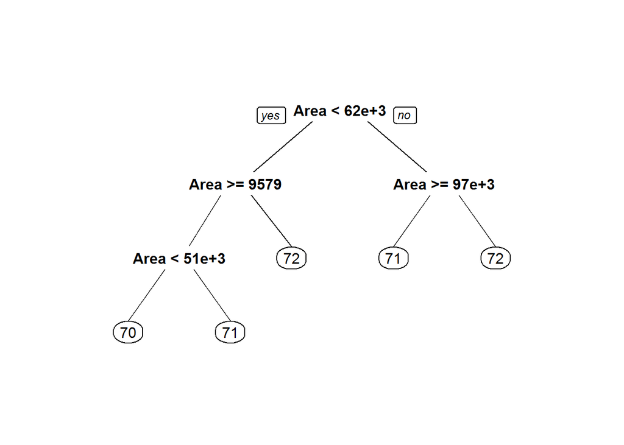

```r
tunedCARTAreaOnly = rpart(Life.Exp~Area, data=states, cp=0.01)
prp(tunedCARTAreaOnly)
```

```r
tunedCARTAreaOnlyPreds = predict(tunedCARTAreaOnly)
sum((tunedCARTAreaOnlyPreds-states$Life.Exp)^2)
```

```
## [1] 44.26817
```